# Cyclistic Bike-Share Analysis

Paris Loyo

June 2025

# 🚲 Introduction

This report analyzes the **Cyclistic bike-share data for 2024**, focusing on usage patterns by day of the week, time of day, and month, with comparisons between **casual** and **member** riders. The analysis was performed in **R**, with visualizations created using `ggplot2`.

# 📚 Data Loading and Setup

```r
# Load libraries
library(tidyverse)  # Includes dplyr, ggplot2, and other packages for data analysis
library(lubridate)  # For handling date and time objects (e.g., extracting hours)
library(skimr)      # For quick summary statistics of the dataset
library(scales)     # For formatting numbers (e.g., adding commas to large numbers)
# Load cleaned bike share data (12 months combined)
bike_data <- read_csv("../data/cleaned/2024_bike_data_combined.csv")
```

# 📝 Descriptive Analysis

## 1. Summary Statistics by User Type

```r
# Summary statistics for ride duration by user type
summary_stats <- bike_data %>%
  group_by(member_casual) %>%
  summarise(
    avg_duration = mean(ride_length),
    median_duration = median(ride_length),
    max_duration = max(ride_length),
    min_duration = min(ride_length),
    sd_duration = sd(ride_length),
    ride_count = n()
  )

# Display summary statistics
summary_stats
```

```
## # A tibble: 2 × 7
##   member_casual avg_duration median_duration max_duration min_duration
##   <chr>                <dbl>           <dbl>        <dbl>        <dbl>
## 1 casual                24.2            13.6        1440.         1.02
## 2 member                12.6             8.9        1438.         1.02
## # ℹ 2 more variables: sd_duration <dbl>, ride_count <int>
```

## 2. Rides by Day of the Week

```r
# Ensure 'day_of_week' is a factor with ordered levels from Sunday to Saturday
bike_data$day_of_week <- factor(bike_data$day_of_week, levels = c("Sun", "Mon", "Tue", "Wed", "Thu", "Fri", "Sat"))

# Rides by day of the week and user type
rides_by_day <- bike_data %>%
  group_by(member_casual, day_of_week) %>%
  summarise(rides = n(), avg_duration = mean(ride_length)) %>%
  arrange(member_casual)
# Display results
rides_by_day
```

```
## # A tibble: 14 × 4
## # Groups:   member_casual [2]
##    member_casual day_of_week  rides avg_duration
##    <chr>         <fct>        <int>        <dbl>
##  1 casual        Sun         263360         27.8
##  2 casual        Mon         179826         23.3
##  3 casual        Tue         161283         20.7
##  4 casual        Wed         185588         21.5
##  5 casual        Thu         181296         21.0
##  6 casual        Fri         220256         23.3
##  7 casual        Sat         314437         27.4
##  8 member        Sun         292777         14.1
##  9 member        Mon         395691         12.0
## 10 member        Tue         417745         12.0
## 11 member        Wed         442700         12.2
## 12 member        Thu         410543         12.0
## 13 member        Fri         373219         12.2
## 14 member        Sat         329352         14.1
```

*Insights: - Casual riders show a preference for weekends, whereas members use the bikes more frequently on weekdays, particularly for commuting.*

*Visualization:*

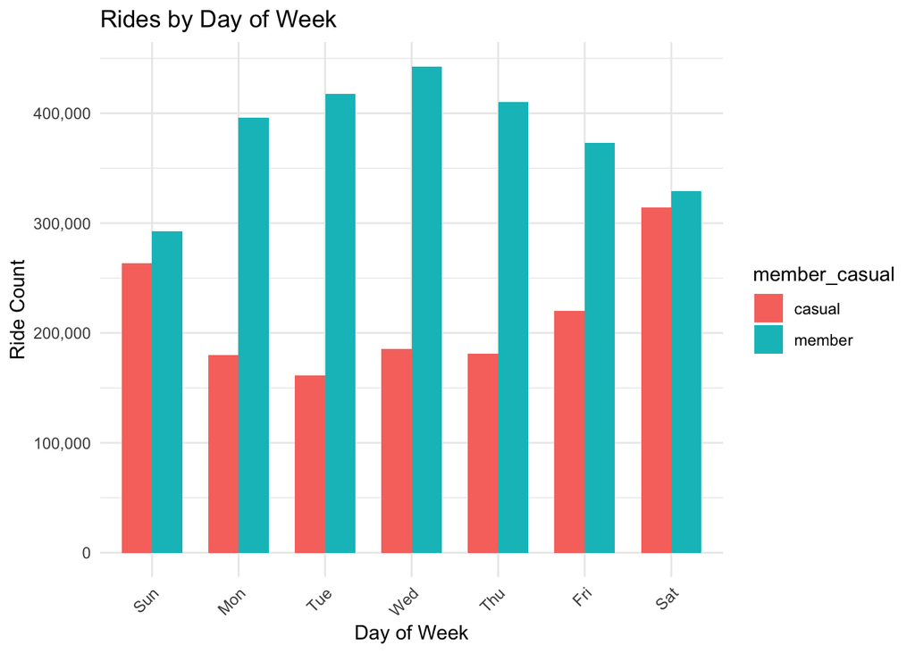

```r
ggplot(rides_by_day, aes(x = day_of_week, y = rides, fill = member_casual)) +
  geom_col(width = 0.7, position = "dodge") +
  scale_y_continuous(labels = label_comma()) +
  labs(title = "Rides by Day of Week", x = "Day of Week", y = "Ride Count") +
  theme_minimal() +
  theme(axis.text.x = element_text(angle = 45, hjust = 1))
```

Save the plot as PNG:

```r
ggsave("../charts/4.1_Rides_by_Day_of_Week.png", plot = last_plot(), width = 10, height = 6)
```

## 3. Rides by Hour of Day

```r
# Extract 'hour_of_day' from 'started_at' timestamp
bike_data <- bike_data %>%
  mutate(hour_of_day = hour(started_at))

# Group by user type and hour of day
rides_by_time <- bike_data %>%
  group_by(member_casual, hour_of_day) %>%
  summarise(rides = n())
# Display results
rides_by_time
```

```
## # A tibble: 48 × 3
## # Groups:   member_casual [2]
##    member_casual hour_of_day rides
##    <chr>               <int> <int>
##  1 casual                  0 21960
##  2 casual                  1 14579
##  3 casual                  2  8615
##  4 casual                  3  4677
##  5 casual                  4  3665
##  6 casual                  5  8182
##  7 casual                  6 19959
##  8 casual                  7 38436
##  9 casual                  8 53923
## 10 casual                  9 54720
## # ℹ 38 more rows
```

*Insights: - Ride counts peak during the afternoon/evening for both members and casual riders, with a notable difference in timing patterns between the two groups.*

*Visualization:*

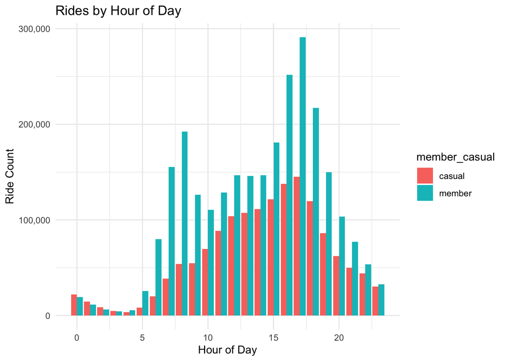

```r
ggplot(rides_by_time, aes(x = hour_of_day, y = rides, fill = member_casual)) +
  geom_col(position = "dodge") +
  scale_y_continuous(labels = label_comma()) +
  labs(title = "Rides by Hour of Day", x = "Hour of Day", y = "Ride Count") +
  theme_minimal()
```

Save the plot as PNG:

```r
ggsave("../charts/4.3_Rides_by_Hour_of_Day.png", plot = last_plot(), width = 10, height = 6)
```

## 4. Rides by Month

```r
# Group by month and user type
rides_by_month <- bike_data %>%
  group_by(member_casual, month) %>%
  summarise(rides = n())
# Order months from Jan to Dec
rides_by_month <- rides_by_month %>%
  mutate(month = factor(month, levels = month.abb))

# Display results
rides_by_month
```

```
## # A tibble: 24 × 3
## # Groups:   member_casual [2]
##    member_casual month  rides
##    <chr>         <fct>  <int>
##  1 casual        Apr    92211
##  2 casual        Aug   226797
##  3 casual        Dec    28009
##  4 casual        Feb    37609
##  5 casual        Jan    17367
##  6 casual        Jul   230157
##  7 casual        Jun   206688
##  8 casual        Mar    61792
##  9 casual        May   164316
## 10 casual        Nov    68393
## # ℹ 14 more rows
```

*Visualization:*

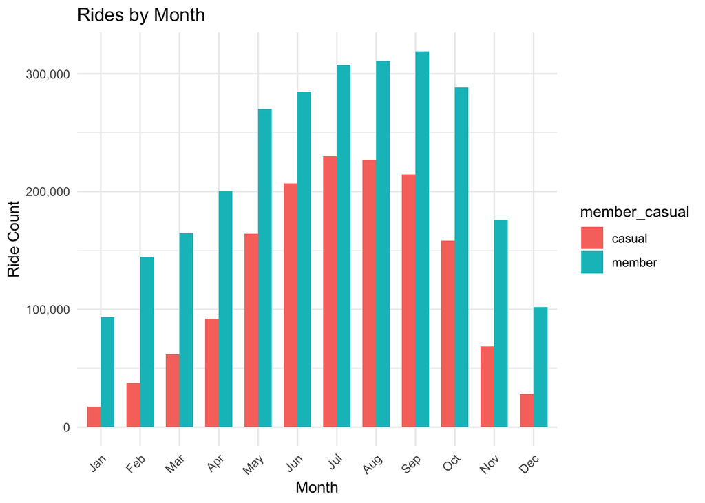

```r
ggplot(rides_by_month, aes(x = month, y = rides, fill = member_casual)) +
  geom_col(width = 0.7, position = "dodge") +
  scale_y_continuous(labels = label_comma()) +
  labs(title = "Rides by Month", x = "Month", y = "Ride Count") +
  theme_minimal() +
  theme(axis.text.x = element_text(angle = 45, hjust = 1))
```

Save the plot as PNG:

```r
ggsave("../charts/4.4_Rides_by_Month.png", plot = last_plot(), width = 10, height = 6)
```

# 🧠 Conclusion

This exploratory data analysis on the Cyclistic bike-share data for 2024 provides valuable insights into user behavior:

- Casual riders generally take longer rides and prefer weekends, while members use bikes more frequently during the week, likely for commuting.
- Peak ride times occur in the late afternoon/evening for both groups.
- Summer months see a significant increase in usage, especially among casual riders.

These findings can be useful for marketing strategies, resource allocation, and optimizing the customer experience for both types of riders.

## 📁 Data and Code

You can access the raw data and cleaned data through the following links:

- [Download Raw Data](https://drive.google.com/drive/folders/19ub7eU1bojJBG4bacEHn1UdlZxR4tpZg?usp=drive_link)
- [Download Cleaned Data](https://drive.google.com/drive/folders/1qeE-V3HxAP0L6tmzZL2Jieo94Ak5qHwY?usp=drive_link)

**Notes:**

This report is designed to be reproducible. If you’d like to recreate the analysis, please ensure that the required packages (`tidyverse`, `lubridate`, `skimr`, `scales`) are installed and that the data files are correctly loaded.

## 💻 Author

Feel free to reach out if you have any questions or need further clarification. Connect with me on [LinkedIn](https://linkedin.com/in/parisloyo).